# MSc-ESC

# Section 2 - Exploratory Analysis

This section conducts an exploratory analysis of the raw data. Specifically for visualizing and deriving descriptive statistics on the data In order to understand the underlying the structures and patterns in the data. A variety of descriptive statistics will be generated for both the numeric data and the categorical data. Similarly a variety of visualizations will be generated for both the numeric data and the categorical data. Further more some visualization on the patterns of diaspora will be generated using Social Networks

```r
# Load in relevant libraries
library(rmarkdown)
library(knitr)
library(igraph)
library(ggplot2)
library(dplyr)
# load in custom utility functions
source("./scripts/utilities/factor_descriptive_statistics.R")
source("./scripts/utilities/numeric_descriptive_statistics.R")
source("./scripts/utilities/plot_bar_chart.R")
source("./scripts/utilities/plot_histogram.R")
source("./scripts/utilities/plot_scatter.R")
source("./scripts/utilities/chisq_assoc_test.R")
source("./scripts/utilities/corr_tests.R")
source("./scripts/utilities/pred_corr_tests.R")
source("./scripts/utilities/graph_network.R")


# load in the raw ESC 2016 data for the analysis
ESCdata <- read.csv(file = "./data/ESC_2016_voting_data.csv", header = T)
```

```r
# define vectors for all numeric columns
avg_point_num <- c('Average_Points')
mig_num <- c('FC_NonCOB', 'FC_NonCitzens', 'FC_COB', 'FC_Citizens', 'FC_Population', 'METRIC_COB', 'METRIC_Citizens', 'METRIC_COBCit')
mus_num <- c('danceability', 'loudiness', 'liveness', 'energy', 'speechiness', 'acousticness', 'instrumentalness', 'acousticness', 'valence', 'tempo', 'duration_ms')
demo_num <- c('TC_NumNeigh', 'FC_CAP_LON', 'FC_CAP_LAT', 'TC_CAP_LON', 'TC_CAP_LAT', 'FC_GDP_mil', 'TC_GDP_mil', 'GDP_PROP', 'CAP_DIST_km')
comp_num <- c('OOA')
# consolidate all numeric columns
all_num <- c(avg_point_num, mig_num, mus_num, demo_num, comp_num)

# define vectors for all categorical columns
voting_factors <- c('From_country', 'To_country', 'Points')
comp_factors <- c('Round', 'Voting_Method', 'Host_Nation', 'OOA')
ext_factors <- c('VBlocs1_TC', 'VBlocs2_TC', 'VBlocs1_FC', 'VBlocs2_FC', 'ComVBlocs1', 'ComVBlocs2', 'FC_LANGFAM', 'TC_LANGFAM', 'ComLANGFAM', 'Neighbours', 'TC_NumNeigh')
perf_factors <- c('FC_SONGLANG', 'TC_SONGLANG','ComSONGLAN', 'TC_PerfType', 'TC_SingerGender', 'key', 'mode', 'time_signature')
# consolidate all factor columns
all_factors <- c(voting_factors, comp_factors, ext_factors, perf_factors)
```

## Descriptive Statistics

Here relevant descriptive statistics are derived for the exploratory analysis. Two custom function are used to generate the descriptive statistics in twp separate data frames. specifically for categorical data and numeric data.

```r
# run the categorical descriptive statistics function
raw_data_cat_desc_stats <- factor_descriptive_statistics(dataset = ESCdata, col_names = all_factors)
# write the categorical descriptive statistics to disk
write.csv(x = raw_data_cat_desc_stats, file = "./report/stats/categorical_descriptive_statistics.csv")

# generate numeric descriptive statistics
raw_data_num_desc_stats <- numeric_descriptive_statistics(dataset = ESCdata, col_names = all_num)
# write the numeric descriptive statistics to disk
write.csv(x = raw_data_num_desc_stats, file = "./report/stats/numeric_descriptive_statistics.csv")
```

## Individual Variable Plots

This section generates a variety of data visualizations. To display the underlying structures within each variable. Bar charts are generated for each categorical variable. histograms are generated for each numeric variable.

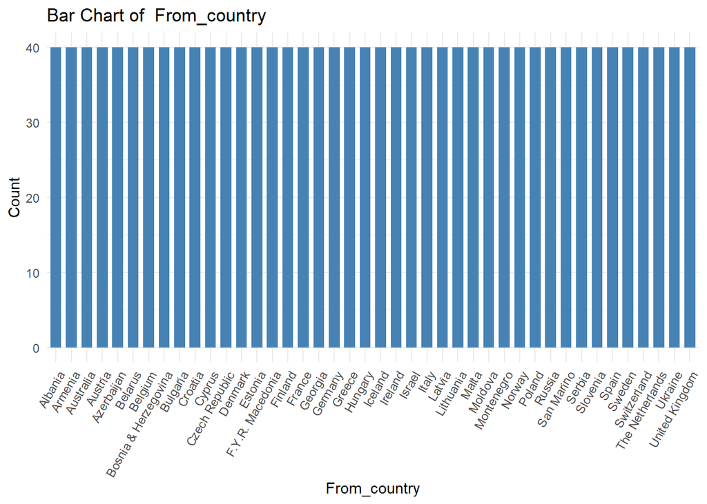

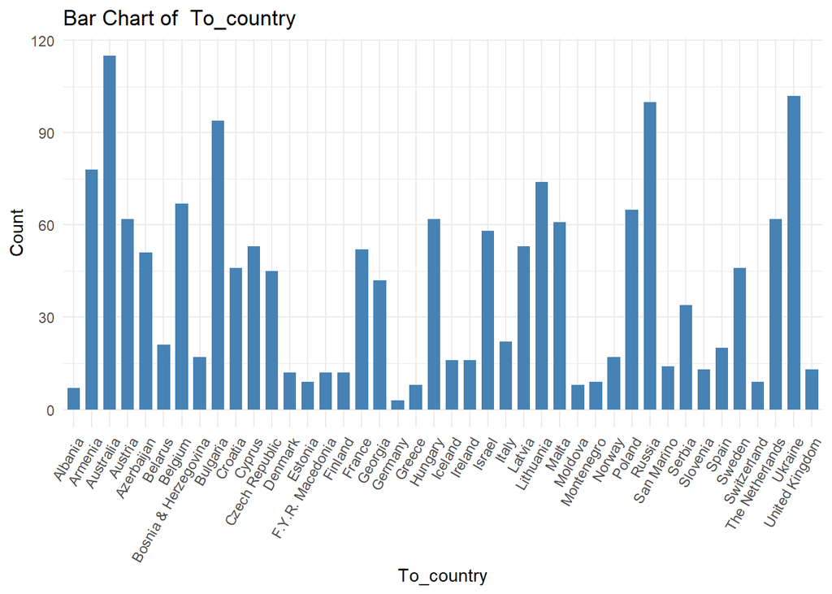

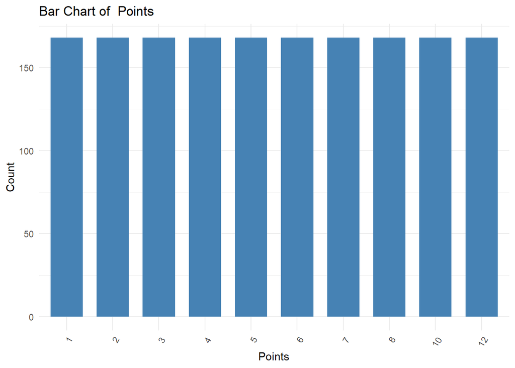

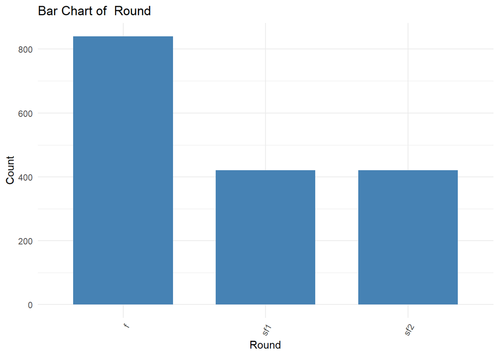

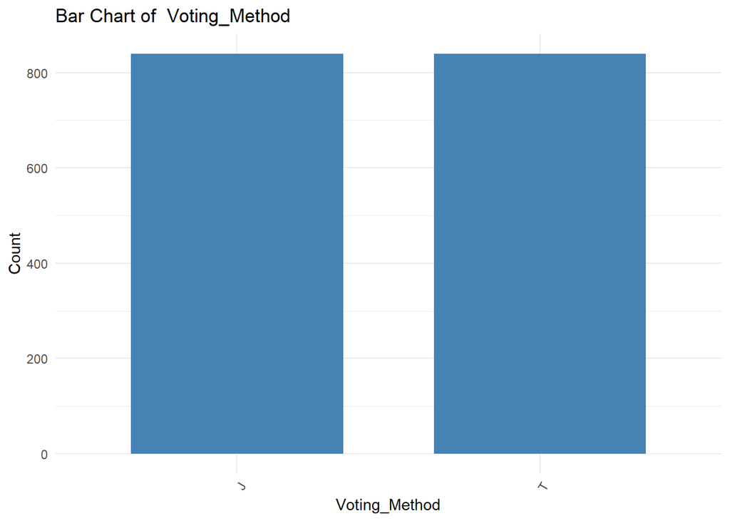

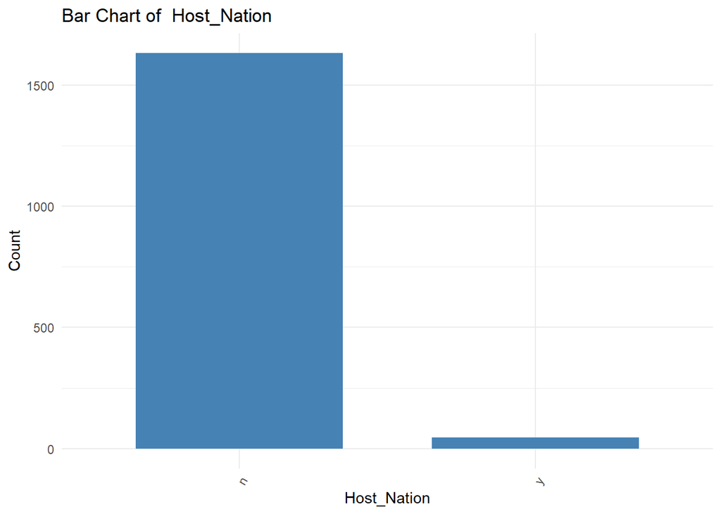

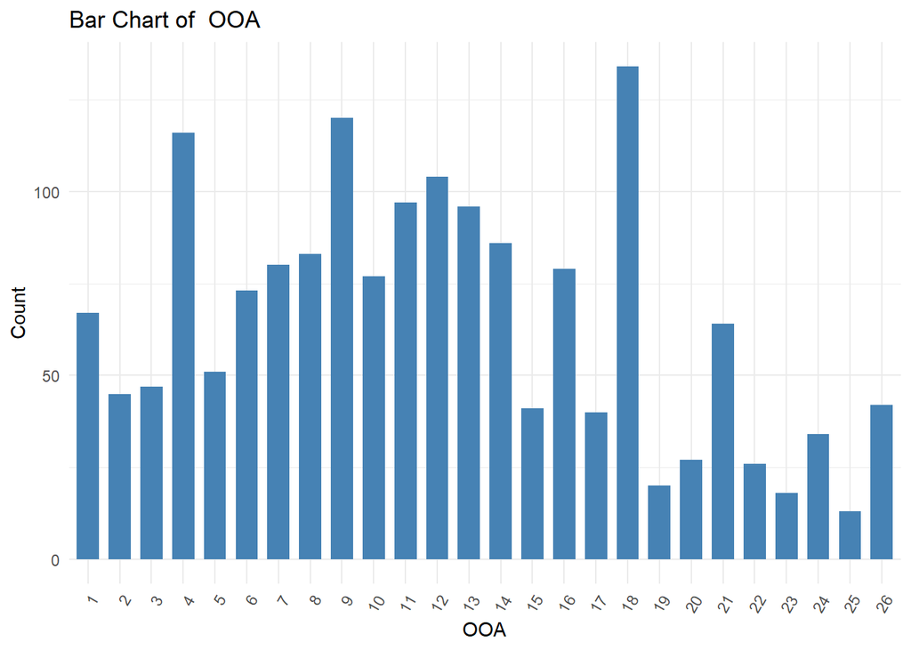

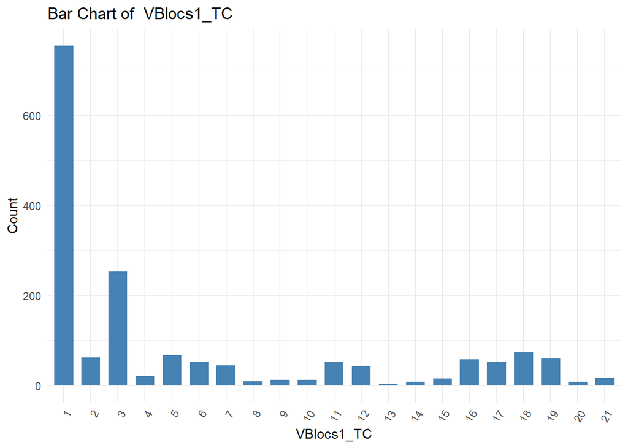

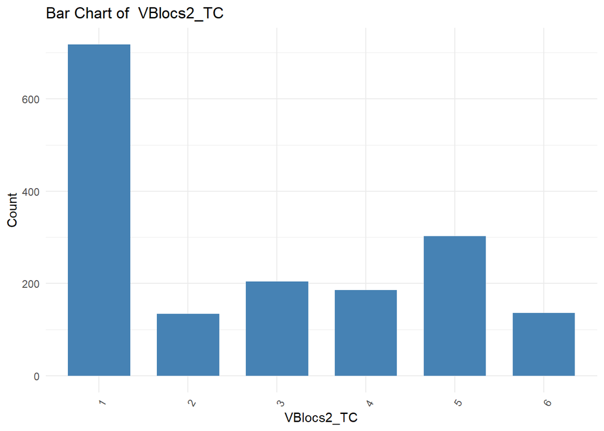

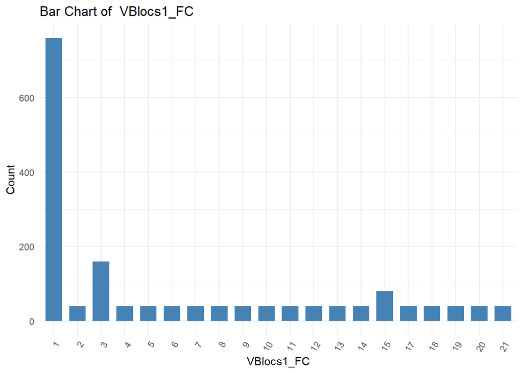

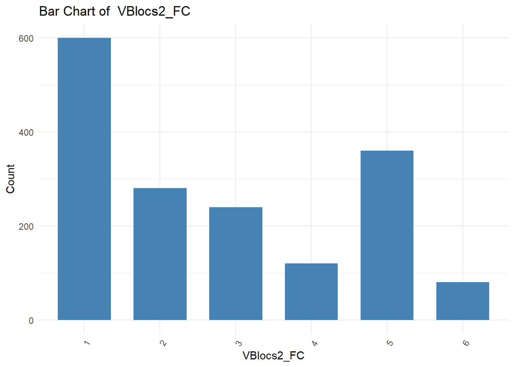

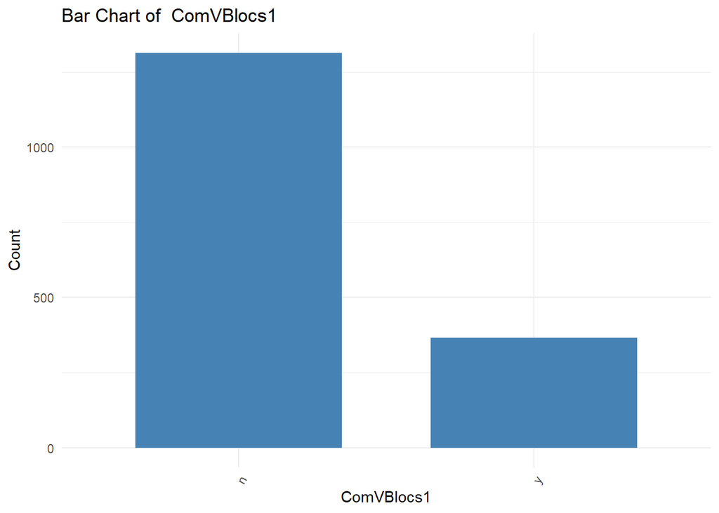

[14 more figures not shown]

```
## [1] 0
```

```r
# call bar chart plotting function
plot_bar_chart(dataset = ESCdata, col_names = all_factors, output_dir = './report/plots/bar_charts')
```

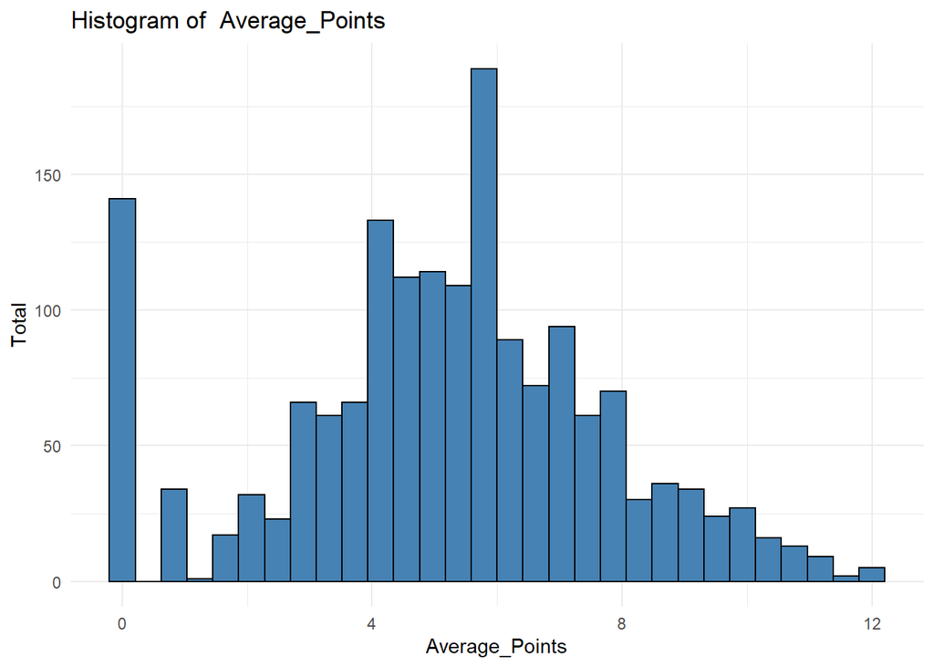

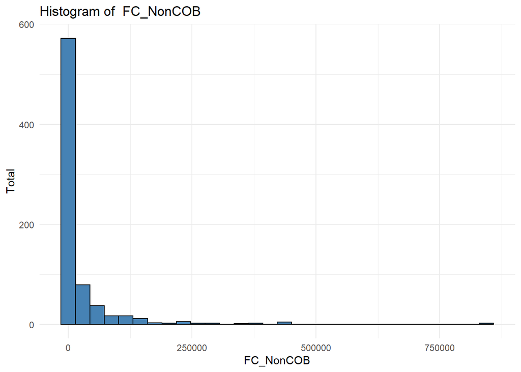

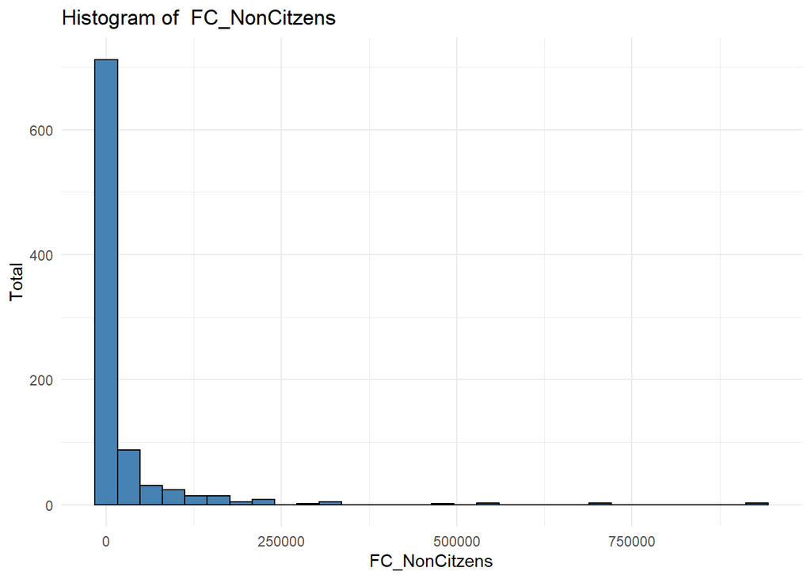

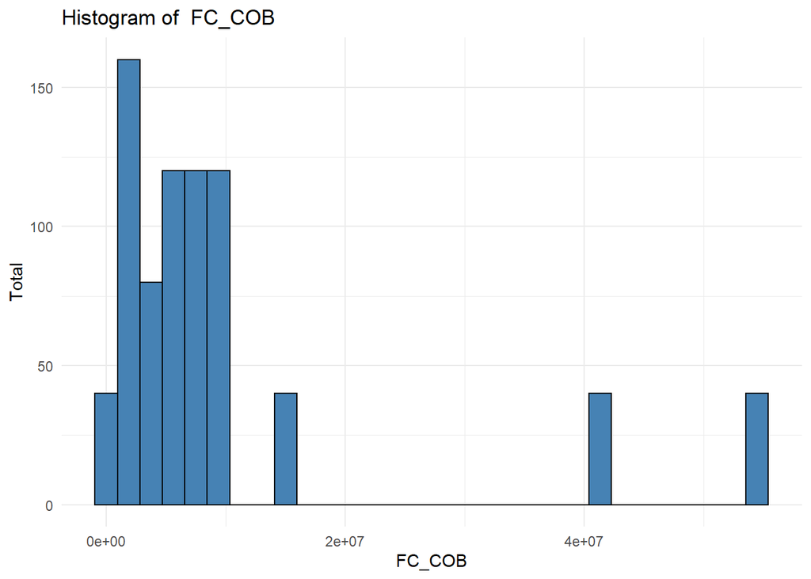

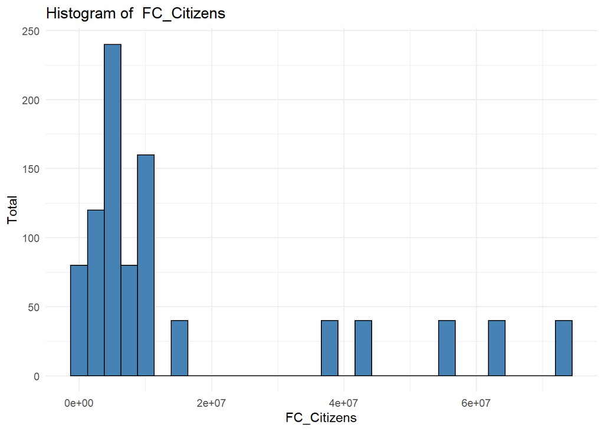

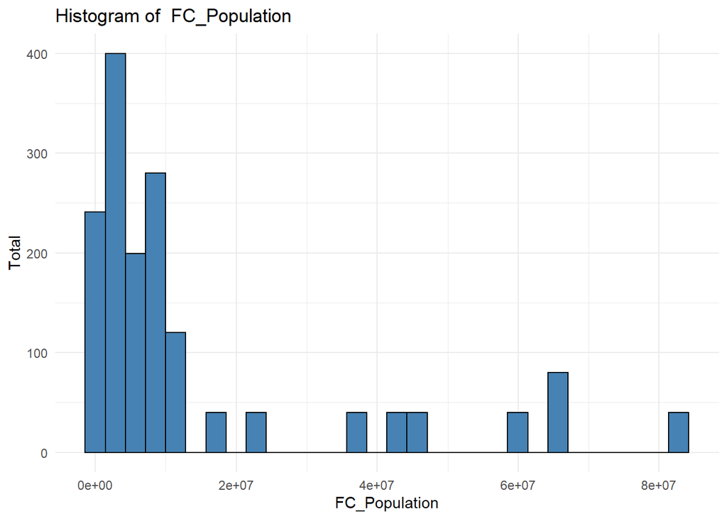

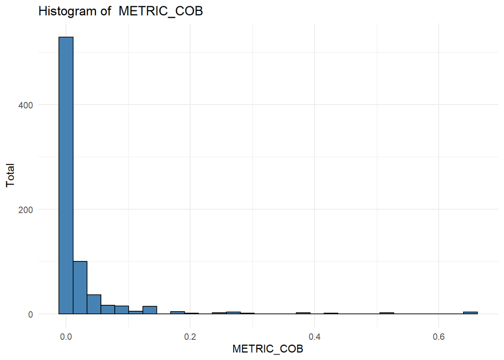

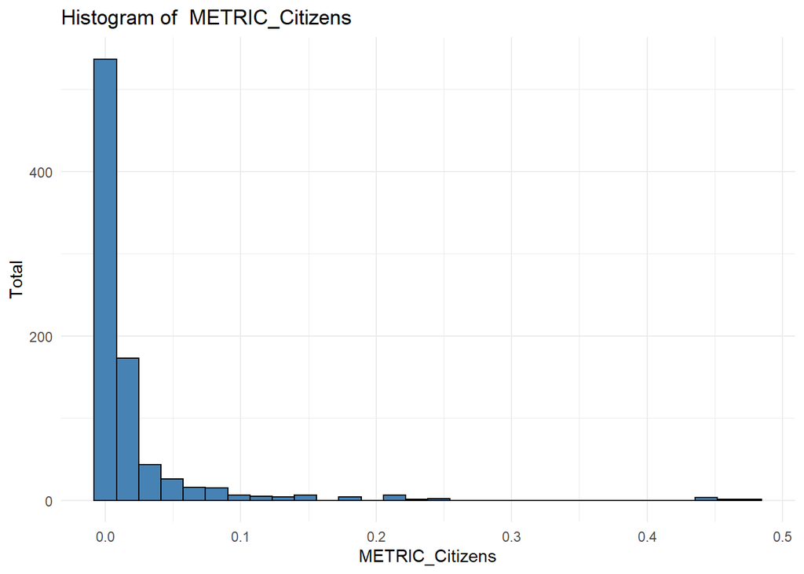

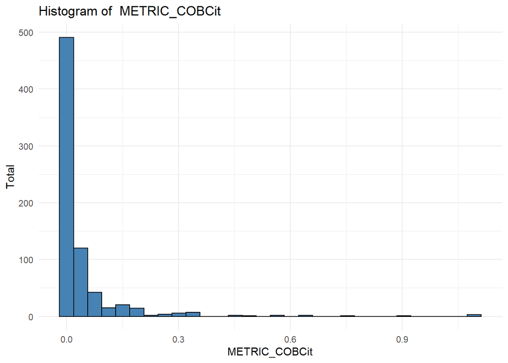

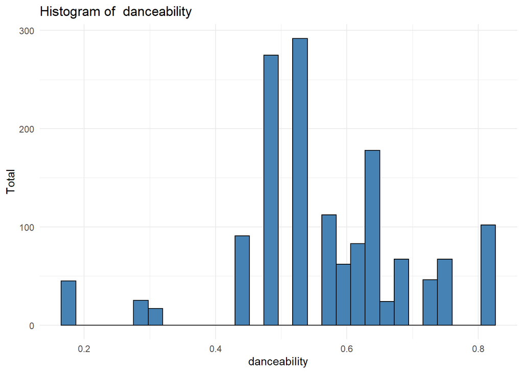

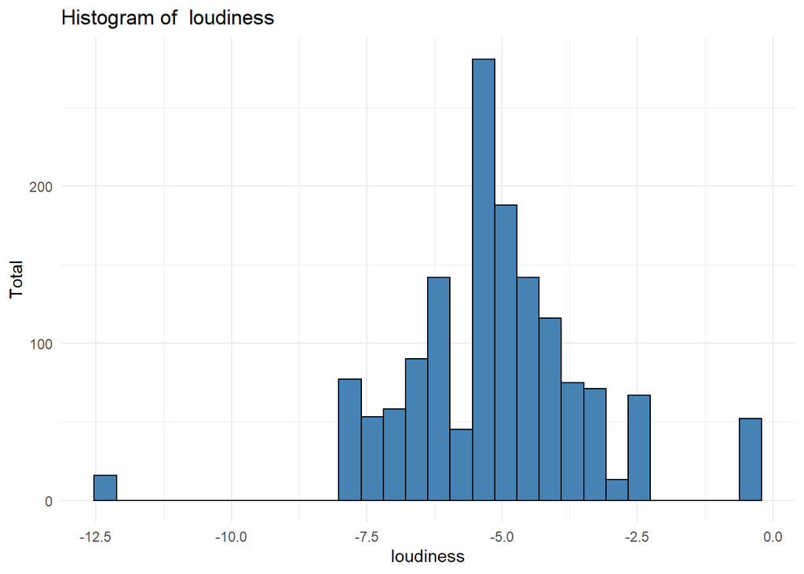

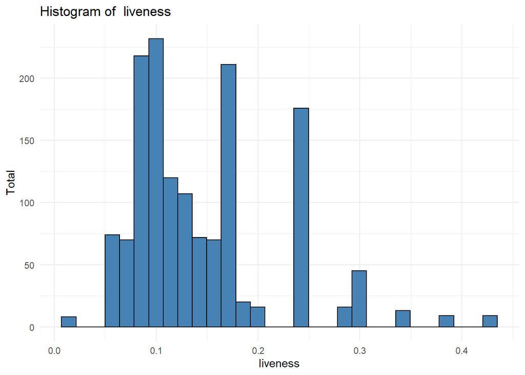

[18 more figures not shown]

```
## [1] 0
```

```r
# call histogram plotting function
plot_histogram(dataset = ESCdata, col_names = all_num, output_dir = './report/plots/histograms')
```

## Chi-squared Tests of Association

This section conducts chi-squared tests of association for each categorical predictor variable and the response variable

Hypothesis: Ho: x is independent of y Ha: x is associated with y

```r
# perform chi-sq tests of association with Points
chisqtestdf <- chisq_assoc_test(data = ESCdata, col_names = all_factors)
# write the data frame to a csv file
write.csv(x = chisqtestdf, file = "./report/stats/chi_sq_tests_response.csv", row.names = F)
```

## Correlation Scatter Plots and Correlation Tests

Correlation Test Hypothesis Ho: x is not correlated with y Ha: x is correlated with y